# EAS 508 Assignment 2– username: alolla and ub number: 50559685

Lolla Aditya Srivatsav

```r
library(ISLR2)
library(ggplot2)
library(MASS)
library(car)
library(class)
```

In case you need to write math expression, please use the quick tutorial as the reference: https://www1.cmc.edu/pages/faculty/aaksoy/latex/latexthree.html

# Question 1 [5 points]

Describe a situation or problem from your job, everyday life, current events, etc., for which a logistic regression model would be appropriate. List some (up to 5) predictors that you might use.

Please show your work. Lets Consider a situation where a marketing team wants to predict a customer will purchase a product on various aspects and behavioral characteristics. Lets develop a predictive model on the customers and their purchasing behavior. 1.Age: Age is one of the significant predictor where the behavior of purchase of an item is going to be varied as per the age group. 2. Income: The level of income in a family is important as the purchase is going to differed as per the Income. 3. Gender: The buying pattern is going to be different as per the gender. 4. Website Visits: The website visit is going to be differed as per the age where a working professional visits the different business websites for the research data and the growing up kid visits the Youtube for the Cartoon channels. 5. Previous Purchases: The customer an their behavior depends on the previous purchases and the hospitality of the certain company or the shopkeeper. If the Material is good enough the customer is going to repeat the purchase in the same company.

# Question 2 [20 points]

In this problem, we will use the Naive Bayes algorithm to fit a spam filter by hand. This question does not involve any programming but only derivation and hand calculation. Spam filters are used in all email services to classify received emails as “Spam” or “Not Spam”. A simple approach involves maintaining a vocabulary of words that commonly occur in “Spam” emails and classifying an email as “Spam” if the number of words fromthe dictionary that are present in the email is over a certain threshold. We are given the vocabulary consists of 15 words

$$V = {\text{secret, offer, low, price,
valued, customer, today, dollar, million, sports, is, for, play,
healthy, pizza}}.$$

We will use $V_i$ to represent the $i$th word in $V$ . As our training dataset, we are also given 3 example spam messages,

- million dollar offer for today
- secret offer today
- secret is secret

and 4 example non-spam messages

- low price for valued customer
- play secret sports today
- sports is healthy
- low price pizza

Recall that the Naive Bayes classifier assumes the probability of an input depends on its input feature. The feature for each sample is defined as $x^{(i)}=[x^{(i)}_1, x^{(i)}_2,\cdots, x^{(i)}_p], i=1,\cdots,m$ and the class of the $i$th sample is $y^{(i)}$. In our case the length of the input vector is $p= 15$, which is equal to the number of words in the vocabulary $V$ (hint: recall that how did we define a dummy variable). Each entry $x^{(i)}_j$ is equal to the number of times word $V_j$ occurs in the $i$-th message.

1.[5 points] Calculate class prior $P(y = 0)$ and $P(y = 1)$ from the training data, where $y=0$ corresponds to spam messages, and $y=1$ corresponds to non-spam messages. Note that these class prior essentially corresponds to the frequency of each class in the training sample. Write down the predictor vectors for each spam and non-spam messages.

```r
Vocabulary <- c("secret", "offer", "price", "valued","customer", "today", "dollar", "million", "sports", "is", "for", "play", "healthy", "pizza")

# Define the Span Messages
spam_messages <- list(
  "million dollar offer for today",
  "secret offer today",
  "secret is secret"
)

# Define the non-spam messages
non_spam_messages <- list(
"low price for valued customer",
"play secret sports today",
"sports is healthy",
"low price pizza"
)

# Count number of spam and non-spam messages
num_spam <- length(spam_messages)
num_non_spam <- length(non_spam_messages)

# Total number of messages
total_messages <- num_spam + num_non_spam

#calculate class priorities
P_y0 <- num_spam / total_messages
P_y1 <- num_non_spam / total_messages

# Initiate the Predictor vectors for the spam and non-spam messages
predictor_vector_spam <- matrix(0, nrow = num_spam, ncol = length(Vocabulary))
predictor_vector_non_spam <- matrix(0, nrow = num_non_spam, ncol = length(Vocabulary))

# Define function to count word occurance in a message
count_words <- function(message, Vocab){
  counts <- sapply(Vocab, function(word) sum(grepl(word, message, ignore.case = TRUE)))
  return(counts)
}
#Populate predictor vectors for spam messages
for (i in 1:num_spam) {
  predictor_vector_spam[i, ] <- count_words(spam_messages[[i]], Vocabulary)
}
for (i in 1:num_non_spam) {
  predictor_vector_non_spam[i, ] <- count_words(non_spam_messages[[i]], Vocabulary)
}
# Output class priors and predictor vectors
cat("Class Priors:\n")
```

```
## Class Priors:
```

```r
cat("P(y = 0):", P_y0, "\n")
```

```
## P(y = 0): 0.4285714
```

```r
cat("P(y = 1):", P_y1, "\n\n")
```

```
## P(y = 1): 0.5714286
```

```r
cat("Predictor Vector for Spam Messages:\n")
```

```
## Predictor Vector for Spam Messages:
```

```r
print(predictor_vector_spam)
```

```
##      [,1] [,2] [,3] [,4] [,5] [,6] [,7] [,8] [,9] [,10] [,11] [,12] [,13] [,14]
## [1,]    0    1    0    0    0    1    1    1    0     0     1     0     0     0
## [2,]    1    1    0    0    0    1    0    0    0     0     0     0     0     0
## [3,]    1    0    0    0    0    0    0    0    0     1     0     0     0     0
```

```r
cat("\nPredictor Vector for Non-Spam Messages:\n")
```

```
##
## Predictor Vector for Non-Spam Messages:
```

```r
print(predictor_vector_non_spam)
```

```
##      [,1] [,2] [,3] [,4] [,5] [,6] [,7] [,8] [,9] [,10] [,11] [,12] [,13] [,14]
## [1,]    0    0    1    1    1    0    0    0    0     0     1     0     0     0
## [2,]    1    0    0    0    0    1    0    0    1     0     0     1     0     0
## [3,]    0    0    0    0    0    0    0    0    1     1     0     0     1     0
## [4,]    0    0    1    0    0    0    0    0    0     0     0     0     0     1
```

The message “today is secret” is more likely to be categorized as spam since $P(y=0|x) > P(y=1|x)$.

# Question 3 [16 points]

The provided dataset is a subset of the public data from the 2022 EPA Automotive Trends Report. It will be used to study the effects of various vehicle characteristics on CO2 emissions. The dataset consists of a dataframe with 1703 observations with the following 7 variables:

- Model.Year: year the vehicle model was produced (quantitative)
- Type: vehicle type (qualitative)
- MPG: miles per gallon of fuel (quantitative)
- Weight: vehicle weight in lbs (quantitative)
- Horsepower: vehicle horsepower in HP (quantitative)
- Acceleration: acceleration time (from 0 to 60 mph) in seconds (quantitative)
- CO2: carbon dioxide emissions in g/mi (response variable)

(1).[3 points] Read the data, Fit a multiple linear regression model called model1 using CO2 as the response and all predicting variables. Using $\alpha=0.05$, which of the estimated coefficients that were statistically significant.

```r
model_1 <- read.csv("emissions.csv")
# Fit multiple linear regression model
model_1 <- lm(CO2 ~ Model.Year + Type + MPG + Weight + Horsepower + Acceleration, data = model_1)
# Summarize the model
summary(model_1)
```

```
##
## Call:
## lm(formula = CO2 ~ Model.Year + Type + MPG + Weight + Horsepower +
##     Acceleration, data = model_1)
##
## Residuals:
##     Min      1Q  Median      3Q     Max
## -49.969 -12.299  -4.040   6.126 242.173
##
## Coefficients:
##                Estimate Std. Error t value Pr(>|t|)
## (Intercept)   1.250e+03  2.983e+02   4.190 2.94e-05 ***
## Model.Year   -2.859e-01  1.525e-01  -1.875   0.0609 .
## TypeSUV      -1.594e+01  2.199e+00  -7.249 6.35e-13 ***
## TypeTruck    -1.802e+01  2.201e+00  -8.186 5.24e-16 ***
## TypeVan      -3.082e+01  2.397e+00 -12.854  < 2e-16 ***
## MPG          -1.749e+01  3.507e-01 -49.882  < 2e-16 ***
## Weight        4.978e-02  2.588e-03  19.235  < 2e-16 ***
## Horsepower   -3.460e-01  2.918e-02 -11.858  < 2e-16 ***
## Acceleration  1.333e+00  5.516e-01   2.417   0.0158 *
## ---
## Signif. codes:  0 '***' 0.001 '**' 0.01 '*' 0.05 '.' 0.1 ' ' 1
##
## Residual standard error: 23.3 on 1694 degrees of freedom
## Multiple R-squared:  0.9399, Adjusted R-squared:  0.9396
## F-statistic:  3309 on 8 and 1694 DF,  p-value: < 2.2e-16
```

(2).[2 points] Is the overall regression (model1) significant at an $\alpha$-level of $0.05$? Explain how you determined the answer.

```r
# Perform F-test for overall significance of the regression model
anova_result <- anova(model_1)

# Extract p-value from the ANOVA table
p_value <- anova_result$`Pr(>F)`[1]

# Check if p-value is less than alpha
alpha <- 0.05
if (p_value < alpha) {
  cat("The overall regression (model_1) is significant at an alpha-level of 0.05.\n")
} else {
  cat("The overall regression (model_1) is not significant at an alpha-level of 0.05.\n")
}
```

```
## The overall regression (model_1) is significant at an alpha-level of 0.05.
```

```r
# Output the p-value
cat("p-value:", p_value, "\n")
```

```
## p-value: 0
```

(3).[6 points] **Identifying Influential Data Points** Cook’s Distances

The basic idea behind the measure is to delete the observations one at a time, each time refitting the regression model on the remaining $n-1$ observations. Then, we compare the results using all $n$ observations to the results with the $i$th observation deleted to see how much influence the observation has on the analysis. Analyzed as such, we are able to assess the potential impact each data point has on the regression analysis. One of such a method is called `Cook's distance`. To learn more on Cook’s distance in R, see https://rpubs.com/DragonflyStats/Cooks-Distance.

Create a plot for the Cook’s Distances (use model1). Using a threshold of $1$, are there any outliers? If yes, which data points?

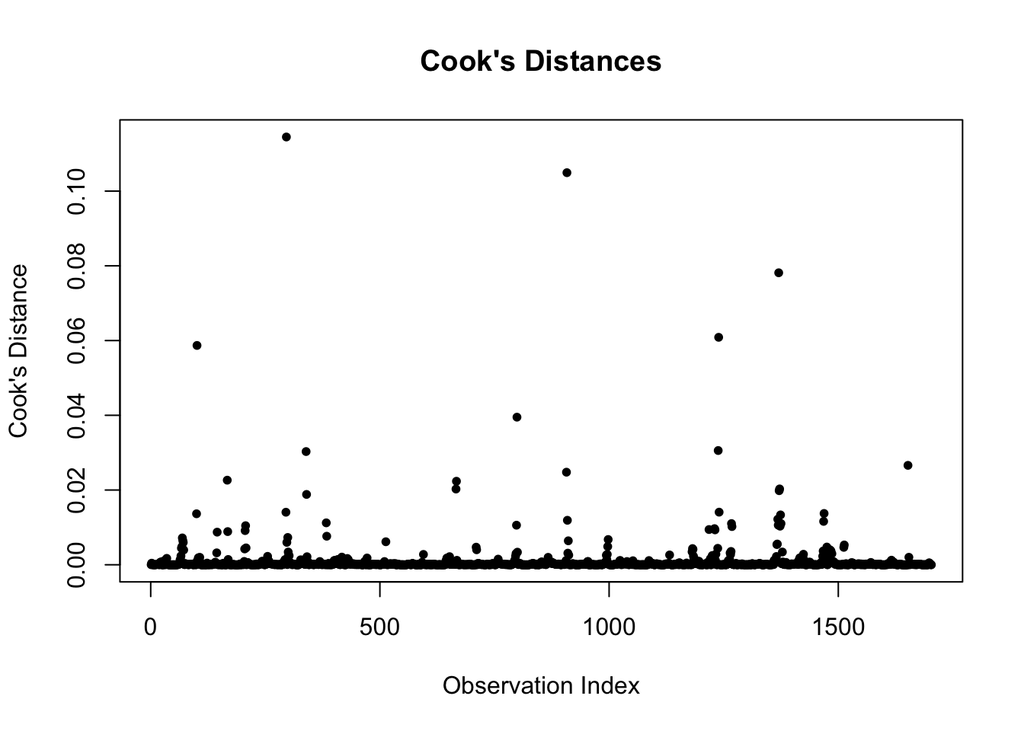

```r
# Calculate Cook's distances
cook_dist <- cooks.distance(model_1)

# Plot Cook's distances
plot(cook_dist, pch = 20, main = "Cook's Distances", xlab = "Observation Index", ylab = "Cook's Distance")

# Add a threshold line at Cook's distance = 1
abline(h = 1, col = "cyan")
```

```r
# Identify outliers
outliers <- which(cook_dist > 1)
if (length(outliers) > 0) {
  cat("Outliers detected at observation indices:", outliers, "\n")
} else {
  cat("No outliers detected.\n")
}
```

```
## No outliers detected.
```

(4).[5 points] **Detecting Multicollinearity Using Variance Inflation Factors (VIF)**

The effects that multicollinearity can have on our regression analyses and subsequent conclusions, how can we tell if multicollinearity is present in our data? A variance inflation factor exists for each of the predictors in a multiple regression model. For example, the variance inflation factor for the estimated regression coefficient $\beta_j$—denoted $VIF_j$ —is just the factor by which the variance of $\beta_j$ is “inflated” by the existence of correlation among the predictor variables in the model.

A VIF of $1$ means that there is no correlation among the $j$th predictor and the remaining predictor variables, and hence the variance of $\beta_j$ is not inflated at all. The general rule of thumb is that VIFs exceeding $4$ warrant further investigation, while VIFs exceeding $10$ are signs of serious multicollinearity requiring correction. For more information, see https://search.r-project.org/CRAN/refmans/usdm/html/vif.html.

Calculate the VIF of each predictor (use model1). Using a threshold of $\max(10, \frac{1}{1-R^2})$ what conclusions can you make regarding multicollinearity?

```r
#load the 'car' package
library(car)
# Calculate VIF values for the each predictor
vif_values <- car::vif(model_1)
# Print VIF Values
print(vif_values)
```

```
##                   GVIF Df GVIF^(1/(2*Df))
## Model.Year   11.158497  1        3.340434
## Type          3.285619  3        1.219278
## MPG           7.387342  1        2.717967
## Weight       11.380489  1        3.373498
## Horsepower   11.459304  1        3.385159
## Acceleration  7.680964  1        2.771455
```

```r
# Check the multicollinearity
threshold <- -10
problematic_predictors <- vif_values[vif_values > threshold]

if(length(problematic_predictors) > 0){
  cat("The following predictors is showing the multicollinearity:\n")
}else{
  cat("No multicollinearity issues detected.\n")
}
```

[output not shown]

# Question 4 [16 points]

(1). Using the GermanCredit data set german.credit (Download the dataset from http://archive.ics.uci.edu/ml/datasets/Statlog+%28German+Credit+Data%29 and read the description), use logistic regression to find a good predictive model for whether credit applicants are good credit risks or not. Show your model (factors used and their coefficients), the output, and the quality of fit. You can use the glm function in R. To get a logistic regression (logit) model on data where the response is either zero or one, use family=binomial in your glm function call. Steps including:

a.[2 points] load the dataset

```r
# Step 1: Load the Dataset
url <- "http://archive.ics.uci.edu/ml/machine-learning-databases/statlog/german/german.data"
data <- read.table(url, header = FALSE, sep = " ")
colnames(data) <- c("existing_account", "duration", "credit_history", "purpose", "credit_amount",
                    "savings_account", "employment_duration", "installment_rate", "personal_status_sex",
                    "other_debtors", "present_residence", "property", "age", "other_installment_plans",
                    "housing", "existing_credits", "job", "dependents", "telephone", "foreign_worker", "credit_risk")

# Step 2: Explore the Dataset
str(data)
```

```
## 'data.frame':    1000 obs. of  21 variables:
##  $ existing_account       : chr  "A11" "A12" "A14" "A11" ...
##  $ duration               : int  6 48 12 42 24 36 24 36 12 30 ...
##  $ credit_history         : chr  "A34" "A32" "A34" "A32" ...
##  $ purpose                : chr  "A43" "A43" "A46" "A42" ...
##  $ credit_amount          : int  1169 5951 2096 7882 4870 9055 2835 6948 3059 5234 ...
##  $ savings_account        : chr  "A65" "A61" "A61" "A61" ...
##  $ employment_duration    : chr  "A75" "A73" "A74" "A74" ...
##  $ installment_rate       : int  4 2 2 2 3 2 3 2 2 4 ...
##  $ personal_status_sex    : chr  "A93" "A92" "A93" "A93" ...
##  $ other_debtors          : chr  "A101" "A101" "A101" "A103" ...
##  $ present_residence      : int  4 2 3 4 4 4 4 2 4 2 ...
##  $ property               : chr  "A121" "A121" "A121" "A122" ...
##  $ age                    : int  67 22 49 45 53 35 53 35 61 28 ...
##  $ other_installment_plans: chr  "A143" "A143" "A143" "A143" ...
##  $ housing                : chr  "A152" "A152" "A152" "A153" ...
##  $ existing_credits       : int  2 1 1 1 2 1 1 1 1 2 ...
##  $ job                    : chr  "A173" "A173" "A172" "A173" ...
##  $ dependents             : int  1 1 2 2 2 2 1 1 1 1 ...
##  $ telephone              : chr  "A192" "A191" "A191" "A191" ...
##  $ foreign_worker         : chr  "A201" "A201" "A201" "A201" ...
##  $ credit_risk            : int  1 2 1 1 2 1 1 1 1 2 ...
```

```r
summary(data)
```

```
##  existing_account      duration    credit_history       purpose
##  Length:1000        Min.   : 4.0   Length:1000        Length:1000
##  Class :character   1st Qu.:12.0   Class :character   Class :character
##  Mode  :character   Median :18.0   Mode  :character   Mode  :character
##                     Mean   :20.9
##                     3rd Qu.:24.0
##                     Max.   :72.0
##  credit_amount   savings_account    employment_duration installment_rate
##  Min.   :  250   Length:1000        Length:1000         Min.   :1.000
##  1st Qu.: 1366   Class :character   Class :character    1st Qu.:2.000
##  Median : 2320   Mode  :character   Mode  :character    Median :3.000
##  Mean   : 3271                                          Mean   :2.973
##  3rd Qu.: 3972                                          3rd Qu.:4.000
##  Max.   :18424                                          Max.   :4.000
##  personal_status_sex other_debtors      present_residence   property
##  Length:1000         Length:1000        Min.   :1.000     Length:1000
##  Class :character    Class :character   1st Qu.:2.000     Class :character
##  Mode  :character    Mode  :character   Median :3.000     Mode  :character
##                                         Mean   :2.845
##                                         3rd Qu.:4.000
##                                         Max.   :4.000
##       age        other_installment_plans   housing          existing_credits
##  Min.   :19.00   Length:1000             Length:1000        Min.   :1.000
##  1st Qu.:27.00   Class :character        Class :character   1st Qu.:1.000
##  Median :33.00   Mode  :character        Mode  :character   Median :1.000
##  Mean   :35.55                                              Mean   :1.407
##  3rd Qu.:42.00                                              3rd Qu.:2.000
##  Max.   :75.00                                              Max.   :4.000
##      job              dependents     telephone         foreign_worker
##  Length:1000        Min.   :1.000   Length:1000        Length:1000
##  Class :character   1st Qu.:1.000   Class :character   Class :character
##  Mode  :character   Median :1.000   Mode  :character   Mode  :character
##                     Mean   :1.155
##                     3rd Qu.:1.000
##                     Max.   :2.000
##   credit_risk
##  Min.   :1.0
##  1st Qu.:1.0
##  Median :1.0
##  Mean   :1.3
##  3rd Qu.:2.0
##  Max.   :2.0
```

```r
# Step 3: Data Preprocessing
# Convert categorical variables to factors
data[c("existing_account", "credit_history", "purpose", "savings_account", "employment_duration","personal_status_sex", "other_debtors", "property", "other_installment_plans","housing", "job", "telephone", "foreign_worker", "credit_risk")] <- lapply(data[c("existing_account", "credit_history", "purpose", "savings_account", "employment_duration",                 "personal_status_sex","other_debtors", "property", "other_installment_plans","housing", "job", "telephone", "foreign_worker", "credit_risk")], factor)

# Step 4: Split Data
set.seed(123) # for reproducibility
train_index <- sample(1:nrow(data), 0.7 * nrow(data))
train_data <- data[train_index, ]
test_data <- data[-train_index, ]

# Step 5: Model Building
model <- glm(credit_risk ~ ., data = train_data, family = binomial)

# Step 6: Model Evaluation
summary(model)
```

```
##
## Call:
## glm(formula = credit_risk ~ ., family = binomial, data = train_data)
##
## Coefficients:
##                               Estimate Std. Error z value Pr(>|z|)
## (Intercept)                 -1.131e+00  1.371e+00  -0.826 0.409079
## existing_accountA12         -2.300e-01  2.707e-01  -0.850 0.395436
## existing_accountA13         -7.906e-01  4.579e-01  -1.727 0.084217 .
## existing_accountA14         -1.607e+00  2.887e-01  -5.565 2.63e-08 ***
## duration                     3.316e-02  1.113e-02   2.979 0.002891 **
## credit_historyA31            3.886e-01  7.048e-01   0.551 0.581384
## credit_historyA32           -6.438e-01  5.712e-01  -1.127 0.259669
## credit_historyA33           -6.974e-01  6.299e-01  -1.107 0.268225
## credit_historyA34           -1.499e+00  5.748e-01  -2.607 0.009130 **
## purposeA41                  -1.871e+00  4.589e-01  -4.077 4.57e-05 ***
## purposeA410                 -1.448e+00  9.904e-01  -1.462 0.143799
## purposeA42                  -8.020e-01  3.284e-01  -2.442 0.014589 *
## purposeA43                  -8.683e-01  3.108e-01  -2.794 0.005209 **
## purposeA44                  -1.960e-01  9.672e-01  -0.203 0.839403
## purposeA45                   3.885e-01  7.031e-01   0.553 0.580580
## purposeA46                  -5.850e-01  5.131e-01  -1.140 0.254256
## purposeA48                  -1.452e+00  1.357e+00  -1.070 0.284801
## purposeA49                  -9.212e-01  4.239e-01  -2.173 0.029769 *
## credit_amount                1.460e-04  5.318e-05   2.746 0.006033 **
## savings_accountA62          -4.910e-01  3.662e-01  -1.341 0.180073
## savings_accountA63          -9.304e-01  5.278e-01  -1.763 0.077903 .
## savings_accountA64          -1.751e+00  6.703e-01  -2.612 0.008995 **
## savings_accountA65          -1.204e+00  3.389e-01  -3.551 0.000384 ***
## employment_durationA72       6.838e-01  5.403e-01   1.266 0.205652
## employment_durationA73       3.936e-01  5.225e-01   0.753 0.451270
## employment_durationA74      -4.145e-01  5.537e-01  -0.749 0.454059
## employment_durationA75      -1.297e-01  5.235e-01  -0.248 0.804266
## installment_rate             3.944e-01  1.090e-01   3.617 0.000298 ***
## personal_status_sexA92       5.229e-02  4.744e-01   0.110 0.912228
## personal_status_sexA93      -6.667e-01  4.672e-01  -1.427 0.153598
## personal_status_sexA94      -1.792e-02  5.530e-01  -0.032 0.974145
## other_debtorsA102            5.693e-01  5.422e-01   1.050 0.293782
## other_debtorsA103           -9.706e-01  5.144e-01  -1.887 0.059191 .
## present_residence            2.448e-02  1.073e-01   0.228 0.819576
```

[output cut: 10 more lines]

```
## jobA173                     -2.913e-02  7.783e-01  -0.037 0.970149
## jobA174                     -2.059e-01  7.808e-01  -0.264 0.791974
## dependents                   4.692e-01  3.096e-01   1.516 0.129584
## telephoneA192               -4.319e-01  2.519e-01  -1.714 0.086482 .
## foreign_workerA202          -1.136e+00  7.597e-01  -1.496 0.134732
## ---
## Signif. codes:  0 '***' 0.001 '**' 0.01 '*' 0.05 '.' 0.1 ' ' 1
##
## (Dispersion parameter for binomial family taken to be 1)
##
##     Null deviance: 844.80  on 699  degrees of freedom
## Residual deviance: 600.93  on 651  degrees of freedom
## AIC: 698.93
##
## Number of Fisher Scoring iterations: 5
```

b.[4 points] explore the dataset, including summary of dataset, types of predictors, if there are categorical predictors, convert the predictors to factors.

```r
# Load the Dataset
url <- "http://archive.ics.uci.edu/ml/machine-learning-databases/statlog/german/german.data"
data <- read.table(url, header = FALSE, sep = " ")
colnames(data) <- c("existing_account", "duration", "credit_history", "purpose", "credit_amount",
                    "savings_account", "employment_duration", "installment_rate", "personal_status_sex",
                    "other_debtors", "present_residence", "property", "age", "other_installment_plans",
                    "housing", "existing_credits", "job", "dependents", "telephone", "foreign_worker", "credit_risk")

# Explore the Dataset
str(data)
```

```
## 'data.frame':    1000 obs. of  21 variables:
##  $ existing_account       : chr  "A11" "A12" "A14" "A11" ...
##  $ duration               : int  6 48 12 42 24 36 24 36 12 30 ...
##  $ credit_history         : chr  "A34" "A32" "A34" "A32" ...
##  $ purpose                : chr  "A43" "A43" "A46" "A42" ...
##  $ credit_amount          : int  1169 5951 2096 7882 4870 9055 2835 6948 3059 5234 ...
##  $ savings_account        : chr  "A65" "A61" "A61" "A61" ...
##  $ employment_duration    : chr  "A75" "A73" "A74" "A74" ...
##  $ installment_rate       : int  4 2 2 2 3 2 3 2 2 4 ...
##  $ personal_status_sex    : chr  "A93" "A92" "A93" "A93" ...
##  $ other_debtors          : chr  "A101" "A101" "A101" "A103" ...
##  $ present_residence      : int  4 2 3 4 4 4 4 2 4 2 ...
##  $ property               : chr  "A121" "A121" "A121" "A122" ...
##  $ age                    : int  67 22 49 45 53 35 53 35 61 28 ...
##  $ other_installment_plans: chr  "A143" "A143" "A143" "A143" ...
##  $ housing                : chr  "A152" "A152" "A152" "A153" ...
##  $ existing_credits       : int  2 1 1 1 2 1 1 1 1 2 ...
##  $ job                    : chr  "A173" "A173" "A172" "A173" ...
##  $ dependents             : int  1 1 2 2 2 2 1 1 1 1 ...
##  $ telephone              : chr  "A192" "A191" "A191" "A191" ...
##  $ foreign_worker         : chr  "A201" "A201" "A201" "A201" ...
##  $ credit_risk            : int  1 2 1 1 2 1 1 1 1 2 ...
```

```r
summary(data)
```

```
##  existing_account      duration    credit_history       purpose
##  Length:1000        Min.   : 4.0   Length:1000        Length:1000
##  Class :character   1st Qu.:12.0   Class :character   Class :character
##  Mode  :character   Median :18.0   Mode  :character   Mode  :character
##                     Mean   :20.9
##                     3rd Qu.:24.0
##                     Max.   :72.0
##  credit_amount   savings_account    employment_duration installment_rate
##  Min.   :  250   Length:1000        Length:1000         Min.   :1.000
##  1st Qu.: 1366   Class :character   Class :character    1st Qu.:2.000
##  Median : 2320   Mode  :character   Mode  :character    Median :3.000
##  Mean   : 3271                                          Mean   :2.973
##  3rd Qu.: 3972                                          3rd Qu.:4.000
##  Max.   :18424                                          Max.   :4.000
##  personal_status_sex other_debtors      present_residence   property
##  Length:1000         Length:1000        Min.   :1.000     Length:1000
##  Class :character    Class :character   1st Qu.:2.000     Class :character
##  Mode  :character    Mode  :character   Median :3.000     Mode  :character
##                                         Mean   :2.845
##                                         3rd Qu.:4.000
##                                         Max.   :4.000
##       age        other_installment_plans   housing          existing_credits
##  Min.   :19.00   Length:1000             Length:1000        Min.   :1.000
##  1st Qu.:27.00   Class :character        Class :character   1st Qu.:1.000
##  Median :33.00   Mode  :character        Mode  :character   Median :1.000
##  Mean   :35.55                                              Mean   :1.407
##  3rd Qu.:42.00                                              3rd Qu.:2.000
##  Max.   :75.00                                              Max.   :4.000
##      job              dependents     telephone         foreign_worker
##  Length:1000        Min.   :1.000   Length:1000        Length:1000
##  Class :character   1st Qu.:1.000   Class :character   Class :character
##  Mode  :character   Median :1.000   Mode  :character   Mode  :character
##                     Mean   :1.155
##                     3rd Qu.:1.000
##                     Max.   :2.000
##   credit_risk
##  Min.   :1.0
##  1st Qu.:1.0
##  Median :1.0
##  Mean   :1.3
##  3rd Qu.:2.0
##  Max.   :2.0
```

```r
# Check types of predictors
sapply(data, class)
```

```
##        existing_account                duration          credit_history
##             "character"               "integer"             "character"
##                 purpose           credit_amount         savings_account
##             "character"               "integer"             "character"
##     employment_duration        installment_rate     personal_status_sex
##             "character"               "integer"             "character"
##           other_debtors       present_residence                property
##             "character"               "integer"             "character"
##                     age other_installment_plans                 housing
##               "integer"             "character"             "character"
##        existing_credits                     job              dependents
##               "integer"             "character"               "integer"
##               telephone          foreign_worker             credit_risk
##             "character"             "character"               "integer"
```

```r
# Convert categorical predictors to factors
categorical_predictors <- c("existing_account", "credit_history", "purpose", "savings_account",
                            "employment_duration", "personal_status_sex", "other_debtors",
                            "property", "other_installment_plans", "housing", "job",
                            "telephone", "foreign_worker", "credit_risk")

data[categorical_predictors] <- lapply(data[categorical_predictors], factor)

# Check the structure and types after conversion
str(data)
```

```
## 'data.frame':    1000 obs. of  21 variables:
##  $ existing_account       : Factor w/ 4 levels "A11","A12","A13",..: 1 2 4 1 1 4 4 2 4 2 ...
##  $ duration               : int  6 48 12 42 24 36 24 36 12 30 ...
##  $ credit_history         : Factor w/ 5 levels "A30","A31","A32",..: 5 3 5 3 4 3 3 3 3 5 ...
##  $ purpose                : Factor w/ 10 levels "A40","A41","A410",..: 5 5 8 4 1 8 4 2 5 1 ...
##  $ credit_amount          : int  1169 5951 2096 7882 4870 9055 2835 6948 3059 5234 ...
##  $ savings_account        : Factor w/ 5 levels "A61","A62","A63",..: 5 1 1 1 1 5 3 1 4 1 ...
##  $ employment_duration    : Factor w/ 5 levels "A71","A72","A73",..: 5 3 4 4 3 3 5 3 4 1 ...
##  $ installment_rate       : int  4 2 2 2 3 2 3 2 2 4 ...
##  $ personal_status_sex    : Factor w/ 4 levels "A91","A92","A93",..: 3 2 3 3 3 3 3 3 1 4 ...
##  $ other_debtors          : Factor w/ 3 levels "A101","A102",..: 1 1 1 3 1 1 1 1 1 1 ...
##  $ present_residence      : int  4 2 3 4 4 4 4 2 4 2 ...
##  $ property               : Factor w/ 4 levels "A121","A122",..: 1 1 1 2 4 4 2 3 1 3 ...
##  $ age                    : int  67 22 49 45 53 35 53 35 61 28 ...
##  $ other_installment_plans: Factor w/ 3 levels "A141","A142",..: 3 3 3 3 3 3 3 3 3 3 ...
##  $ housing                : Factor w/ 3 levels "A151","A152",..: 2 2 2 3 3 3 2 1 2 2 ...
##  $ existing_credits       : int  2 1 1 1 2 1 1 1 1 2 ...
##  $ job                    : Factor w/ 4 levels "A171","A172",..: 3 3 2 3 3 2 3 4 2 4 ...
##  $ dependents             : int  1 1 2 2 2 2 1 1 1 1 ...
##  $ telephone              : Factor w/ 2 levels "A191","A192": 2 1 1 1 1 2 1 2 1 1 ...
##  $ foreign_worker         : Factor w/ 2 levels "A201","A202": 1 1 1 1 1 1 1 1 1 1 ...
##  $ credit_risk            : Factor w/ 2 levels "1","2": 1 2 1 1 2 1 1 1 1 2 ...
```

c.[2 points] Column V21 represents the target, 1 = Good, 2 = Bad, convert value the values to 0 and 1, respectively.

```r
# Convert values in column V21 to 0 and 1
data$credit_risk <- ifelse(data$credit_risk == 1, 0, 1)

# Confirm the conversion
table(data$credit_risk)
```

```
##
##   0   1
## 700 300
```

d.[2 points] split the dataset to taining and test dataset with 90% and 10% of the data points, respectively.

```r
set.seed(123)
n_rows <- nrow(data)
row_indices <- sample(1:n_rows, n_rows, replace = FALSE)
n_train <- round(0.9 * n_rows)
n_test <- n_rows - n_train
train_data <- data[row_indices[1:n_train], ]
test_data <- data[row_indices[(n_train + 1):n_rows], ]
dim(train_data)
```

```
## [1] 900  21
```

```r
dim(test_data)
```

```
## [1] 100  21
```

e.[3 points] use the training dataset to get a logistic regression (logit) model on data where the response is either zero or one, use family=binomial in your glm function call.

```r
logit_model <- glm(credit_risk ~ ., data = train_data, family = binomial)
summary(logit_model)
```

```
##
## Call:
## glm(formula = credit_risk ~ ., family = binomial, data = train_data)
##
## Coefficients:
##                               Estimate Std. Error z value Pr(>|z|)
## (Intercept)                 -1.917e-02  1.183e+00  -0.016 0.987074
## existing_accountA12         -3.695e-01  2.326e-01  -1.589 0.112109
## existing_accountA13         -9.616e-01  3.850e-01  -2.497 0.012514 *
## existing_accountA14         -1.733e+00  2.478e-01  -6.992 2.71e-12 ***
## duration                     2.934e-02  9.775e-03   3.001 0.002690 **
## credit_historyA31            2.586e-01  5.831e-01   0.444 0.657366
## credit_historyA32           -6.742e-01  4.595e-01  -1.467 0.142289
## credit_historyA33           -7.987e-01  4.995e-01  -1.599 0.109803
## credit_historyA34           -1.365e+00  4.628e-01  -2.950 0.003179 **
## purposeA41                  -1.569e+00  3.916e-01  -4.008 6.12e-05 ***
## purposeA410                 -1.619e+00  8.619e-01  -1.879 0.060311 .
## purposeA42                  -7.934e-01  2.804e-01  -2.830 0.004657 **
## purposeA43                  -8.644e-01  2.652e-01  -3.260 0.001115 **
## purposeA44                   3.993e-02  8.209e-01   0.049 0.961207
## purposeA45                   5.813e-02  6.030e-01   0.096 0.923197
## purposeA46                  -2.251e-01  4.231e-01  -0.532 0.594736
## purposeA48                  -2.077e+00  1.298e+00  -1.600 0.109540
## purposeA49                  -8.363e-01  3.551e-01  -2.355 0.018505 *
## credit_amount                1.355e-04  4.669e-05   2.903 0.003700 **
## savings_accountA62          -4.701e-01  3.074e-01  -1.530 0.126119
## savings_accountA63          -3.594e-01  4.081e-01  -0.881 0.378553
## savings_accountA64          -1.347e+00  5.340e-01  -2.522 0.011656 *
## savings_accountA65          -9.795e-01  2.861e-01  -3.423 0.000618 ***
## employment_durationA72      -2.944e-02  4.612e-01  -0.064 0.949112
## employment_durationA73      -1.495e-01  4.455e-01  -0.336 0.737190
## employment_durationA74      -9.106e-01  4.797e-01  -1.898 0.057662 .
## employment_durationA75      -3.903e-01  4.479e-01  -0.871 0.383516
## installment_rate             4.103e-01  9.484e-02   4.327 1.51e-05 ***
## personal_status_sexA92      -2.937e-01  4.151e-01  -0.708 0.479195
## personal_status_sexA93      -9.543e-01  4.113e-01  -2.320 0.020342 *
## personal_status_sexA94      -2.619e-01  4.908e-01  -0.534 0.593616
## other_debtorsA102            3.632e-01  4.391e-01   0.827 0.408117
## other_debtorsA103           -1.026e+00  4.564e-01  -2.249 0.024536 *
## present_residence            1.706e-03  9.231e-02   0.018 0.985253
```

[output cut: 10 more lines]

```
## jobA173                      4.552e-01  7.156e-01   0.636 0.524682
## jobA174                      1.752e-01  7.158e-01   0.245 0.806650
## dependents                   4.267e-01  2.623e-01   1.627 0.103766
## telephoneA192               -2.798e-01  2.145e-01  -1.304 0.192089
## foreign_workerA202          -1.538e+00  7.191e-01  -2.138 0.032482 *
## ---
## Signif. codes:  0 '***' 0.001 '**' 0.01 '*' 0.05 '.' 0.1 ' ' 1
##
## (Dispersion parameter for binomial family taken to be 1)
##
##     Null deviance: 1090.95  on 899  degrees of freedom
## Residual deviance:  792.88  on 851  degrees of freedom
## AIC: 890.88
##
## Number of Fisher Scoring iterations: 5
```

f.[4 points] use the model to make prediction on the the training dataset, and test dataset, give the confusion matrices and accuracy for each dataset.

```r
# Predictions on training dataset
train_predictions <- predict(logit_model, newdata = train_data, type = "response")
train_predictions <- ifelse(train_predictions > 0.5, 1, 0) # Convert probabilities to binary predictions

# Confusion matrix and accuracy for training dataset
train_confusion <- table(Actual = train_data$credit_risk, Predicted = train_predictions)
train_accuracy <- sum(diag(train_confusion)) / sum(train_confusion)

# Predictions on test dataset
test_predictions <- predict(logit_model, newdata = test_data, type = "response")
test_predictions <- ifelse(test_predictions > 0.5, 1, 0) # Convert probabilities to binary predictions

# Confusion matrix and accuracy for test dataset
test_confusion <- table(Actual = test_data$credit_risk, Predicted = test_predictions)
test_accuracy <- sum(diag(test_confusion)) / sum(test_confusion)

# Display confusion matrices and accuracy
cat("Confusion Matrix for Training Dataset:\n")
```

```
## Confusion Matrix for Training Dataset:
```

```r
print(train_confusion)
```

```
##       Predicted
## Actual   0   1
##      0 566  69
##      1 122 143
```

```r
cat("\nAccuracy for Training Dataset:", train_accuracy, "\n")
```

```
##
## Accuracy for Training Dataset: 0.7877778
```

```r
cat("\nConfusion Matrix for Test Dataset:\n")
```

```
##
## Confusion Matrix for Test Dataset:
```

```r
print(test_confusion)
```

```
##       Predicted
## Actual  0  1
##      0 58  7
##      1 17 18
```

```r
cat("\nAccuracy for Test Dataset:", test_accuracy, "\n")
```

```
##
## Accuracy for Test Dataset: 0.76
```

(2). [4 points] Because the model gives a result between $0$ and $1$, it requires setting a threshold probability to separate between “good” and “bad” answers. In this data set, they estimate that incorrectly identifying a bad customer as good, is $5$ times worse than incorrectly classifying a good customer as bad. Determine a good threshold probability based on your model (please demonstrate your reasoning.)

```r
# Step 1: Predict probabilities
probabilities <- predict(model, newdata = test_data, type = "response")

# Step 2: Define the cost function
calculate_cost <- function(threshold, probabilities, actual) {
  predictions <- ifelse(probabilities > threshold, 1, 0)
  fp <- sum((predictions == 1) & (actual == 0)) # Actual good, predicted bad
  fn <- sum((predictions == 0) & (actual == 1)) # Actual bad, predicted good
  cost <- 5 * fp + 1 * fn
  return(cost)
}

# Step 3: Evaluate thresholds
thresholds <- seq(0, 1, by = 0.01)
costs <- sapply(thresholds, function(t) calculate_cost(t, probabilities, test_data$V21))

# Step 4: Find the optimal threshold
optimal_threshold <- thresholds[which.min(costs)]

# Print the optimal threshold
print(optimal_threshold)
```

```
## [1] 0
```

# Question 5 [28 points]

In this problem, you will develop a model to predict whether a given car gets high or low gas mileage based on the `Auto` data set.

(1).[2 points] Create a binary variable, `mpg01`, that contains a $1$ if mpg contains a value above its median, and a $0$ if mpg contains a value below its median. You can compute the median using the `median()` function. Note you may find it helpful to use the data.frame() function to create a single data set containing both `mpg01` and the other `Auto` variables.

```
Answer:
```

```r
library(MASS)
library(caret)
library(ISLR2)
# Load the DataSet
data(Auto)
head(Auto, 5)
```

```
##   mpg cylinders displacement horsepower weight acceleration year origin
## 1  18         8          307        130   3504         12.0   70      1
## 2  15         8          350        165   3693         11.5   70      1
## 3  18         8          318        150   3436         11.0   70      1
## 4  16         8          304        150   3433         12.0   70      1
## 5  17         8          302        140   3449         10.5   70      1
##                        name
## 1 chevrolet chevelle malibu
## 2         buick skylark 320
## 3        plymouth satellite
## 4             amc rebel sst
## 5               ford torino
```

```r
# Compute the median of mpg
mpg_median <- median(Auto$mpg)
# Create mpg01 variable
Auto$mpg01 <- ifelse(Auto$mpg > mpg_median, 1, 0)
# Check the structure of the updated dataset
str(Auto)
```

```
## 'data.frame':    392 obs. of  10 variables:
##  $ mpg         : num  18 15 18 16 17 15 14 14 14 15 ...
##  $ cylinders   : int  8 8 8 8 8 8 8 8 8 8 ...
##  $ displacement: num  307 350 318 304 302 429 454 440 455 390 ...
##  $ horsepower  : int  130 165 150 150 140 198 220 215 225 190 ...
##  $ weight      : int  3504 3693 3436 3433 3449 4341 4354 4312 4425 3850 ...
##  $ acceleration: num  12 11.5 11 12 10.5 10 9 8.5 10 8.5 ...
##  $ year        : int  70 70 70 70 70 70 70 70 70 70 ...
##  $ origin      : int  1 1 1 1 1 1 1 1 1 1 ...
##  $ name        : Factor w/ 304 levels "amc ambassador brougham",..: 49 36 231 14 161 141 54 223 241 2 ...
##  $ mpg01       : num  0 0 0 0 0 0 0 0 0 0 ...
##  - attr(*, "na.action")= 'omit' Named int [1:5] 33 127 331 337 355
##   ..- attr(*, "names")= chr [1:5] "33" "127" "331" "337" ...
```

```r
head(Auto, 5)
```

```
##   mpg cylinders displacement horsepower weight acceleration year origin
## 1  18         8          307        130   3504         12.0   70      1
## 2  15         8          350        165   3693         11.5   70      1
## 3  18         8          318        150   3436         11.0   70      1
## 4  16         8          304        150   3433         12.0   70      1
## 5  17         8          302        140   3449         10.5   70      1
##                        name mpg01
## 1 chevrolet chevelle malibu     0
## 2         buick skylark 320     0
## 3        plymouth satellite     0
## 4             amc rebel sst     0
## 5               ford torino     0
```

(2).[4 points] Explore the data graphically in order to investigate the association between `mpg01` and the other features. Which of the other features seem most likely to be useful in predicting `mpg01`? Scatterplots and boxplots may be useful tools to answer this question. Describe your findings.

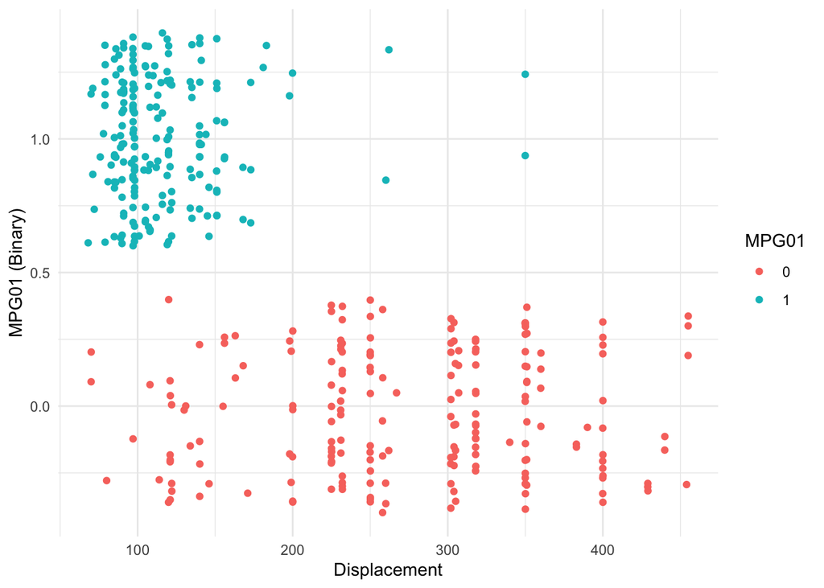

```r
# Scatterplot
# Assuming 'Auto' is your dataset and it includes 'mpg01'
ggplot(Auto, aes(x = displacement, y = mpg01)) +
  geom_jitter(aes(color = factor(mpg01)), width = 0.1) +
  labs(x = "Displacement", y = "MPG01 (Binary)", color = "MPG01") +
  theme_minimal()
```

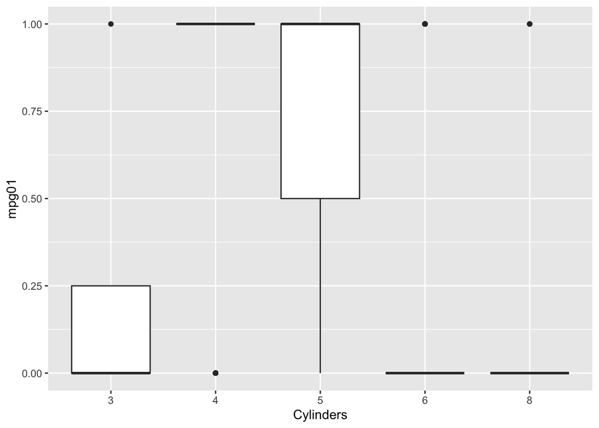

```r
ggplot(Auto, aes(x=factor(cylinders), y=mpg01)) + geom_boxplot() + xlab("Cylinders")
```

(3).[2 points] Split the data into a training set and a test set.

```r
# Load the library
library(caret)
# Set seed for reproductivity
set.seed(123)
# Create the training and set the indices
train_index <- createDataPartition(Auto$mpg01, p = 0.8, list =  FALSE)
# Create training and test sets
train_set <- Auto[train_index, ]
test_set <- Auto[-train_index, ]
```

(4).[3 points] Perform LDA on the training data in order to predict `mpg01` using the variables that seemed most associated with `mpg01` in (2). What is the test error of the model obtained?

```r
# Fit an LDA model on the training data
lda_model <- lda(mpg01 ~ displacement + weight, data = train_set)

# Predict on the test data using the fitted model
lda_predictions <- predict(lda_model, newdata = test_set)

# Create a confusion matrix to evaluate the model's performance
conf_matrix <- table(Predicted = lda_predictions$class, Actual = test_set$mpg01)

# Calculate the test error
test_error <- mean(lda_predictions$class != test_set$mpg01)

# Print out the test error
print(test_error)
```

```
## [1] 0.1410256
```

```r
# Print out the confusion matrix to examine the prediction details
print(conf_matrix)
```

```
##          Actual
## Predicted  0  1
##         0 28  0
##         1 11 39
```

(5).[3 points] Perform QDA on the training data in order to predict `mpg01` using the variables that seemed most associated with `mpg01` in (2). What is the test error of the model obtained?

```r
# Fit QDA model on training data
qda_fit <- qda(mpg01 ~ displacement + weight, data = train_set)

# Predict on test data
qda_pred <- predict(qda_fit, newdata = test_set)

# Create a confusion matrix
conf_matrix_qda <- table(Predicted = qda_pred$class, Actual = test_set$mpg01)

# Calculate test error
test_error_qda <- mean(qda_pred$class != test_set$mpg01)

# Print out the test error for QDA
cat("QDA Test Error:", test_error_qda, "\n")
```

```
## QDA Test Error: 0.1025641
```

```r
# Print out the confusion matrix for QDA
print(conf_matrix_qda)
```

```
##          Actual
## Predicted  0  1
##         0 33  2
##         1  6 37
```

(6). [3 points] Perform logistic regression on the training data in order to predict `mpg01` using the variables that seemed most associated with `mpg01` in (2). What is the test error of the model obtained?

```r
# Fit logistic regression model on training data
logit_fit <- glm(mpg01 ~ displacement + weight, family = binomial, data = train_set)

# Predict on test data
logit_probs <- predict(logit_fit, newdata = test_set, type = "response")
logit_pred <- as.numeric(logit_probs > 0.5)

# Create a confusion matrix
conf_matrix_logit <- table(Predicted = logit_pred, Actual = test_set$mpg01)

# Calculate test error
test_error_logit <- mean(logit_pred != test_set$mpg01)

# Print out the test error and confusion matrix
cat("Test Error:", test_error_logit, "\n")
```

```
## Test Error: 0.1282051
```

```r
print(conf_matrix_logit)
```

```
##          Actual
## Predicted  0  1
##         0 30  1
##         1  9 38
```

(7). [3 points] Perform naive Bayes on the training data in order to predict `mpg01` using the variables that seemed most associated with `mpg01` in (2). What is the test error of the model obtained?

```r
library(e1071)

# Fit Naive Bayes model on training data
nb_values <- naiveBayes(mpg01 ~ displacement + weight, data=train_set)

# Predict on test data
nb_pred <- predict(nb_values, test_set)

# You could also calculate the test error as previously shown
test_error <- mean(nb_pred != test_set$mpg01)

# You could create a confusion matrix to see the details of the prediction
conf_matrix <- table(Predicted = nb_pred, Actual = test_set$mpg01)

print(test_error)
```

```
## [1] 0.1410256
```

```r
print(conf_matrix)
```

```
##          Actual
## Predicted  0  1
##         0 29  1
##         1 10 38
```

(8). [5 points] Perform KNN on the training data in order to predict `mpg01` using the variables that seemed most associated with `mpg01` in (2). What is the test error of the model obtained? Which value of K seems to perform the best on this data set?

```r
# Load the required packages
library(class)
library(caret)

# Set seed for reproducibility
set.seed(123)

# Prepare the predictors and responses
train_predictors <- scale(train_set[, c("displacement", "weight")])
test_predictors <- scale(test_set[, c("displacement", "weight")])
train_response <- train_set$mpg01

# Define the range of k values to try
k_values <- 1:20
errors <- numeric(length(k_values))

# Perform k-fold cross-validation (e.g., 10-fold)
folds <- createDataPartition(train_response, times = 10, p = 0.8, list = FALSE)

# Loop over each k value
for (k in k_values) {
  fold_errors <- numeric(length(folds))

  # Perform cross-validation for each fold
  for (i in seq_along(folds)) {
    # Split the data
    train_fold <- train_predictors[-folds[[i]], ]
    test_fold <- train_predictors[folds[[i]], ]
    train_fold_response <- train_response[-folds[[i]]]
    test_fold_response <- train_response[folds[[i]]]

    # Train and predict with KNN
    knn_pred <- knn(train = train_fold, test = test_fold, cl = train_fold_response, k = k)

    # Calculate error for the fold
    fold_errors[i] <- mean(knn_pred != test_fold_response)
  }

  # Calculate mean error across folds for the current k
  errors[k] <- mean(fold_errors)
}

# Find the optimal k with the lowest error
optimal_k <- which.min(errors)

# Print the optimal k value
print(paste("Optimal k:", optimal_k))
```

```
## [1] "Optimal k: 6"
```

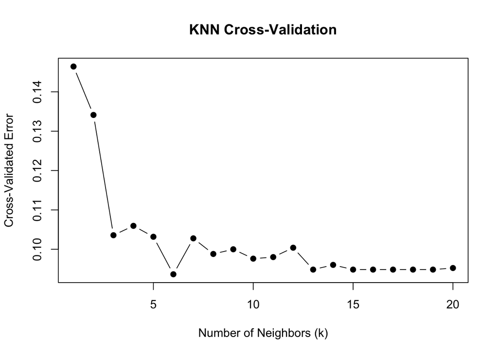

```r
# Plot the cross-validated errors for different k values
plot(k_values, errors, type = "b", pch = 19, main = "KNN Cross-Validation",
     xlab = "Number of Neighbors (k)", ylab = "Cross-Validated Error")
```

```r
# Run KNN with the optimal k on the test data
knn_pred_optimal <- knn(train = train_predictors, test = test_predictors, cl = train_response, k = optimal_k)

# Calculate the test error for the optimal k
test_error_optimal_k <- mean(knn_pred_optimal != test_set$mpg01)

# Output the test error for the optimal k
print(paste("Test Error with Optimal k:", test_error_optimal_k))
```

```
## [1] "Test Error with Optimal k: 0.115384615384615"
```

(9).[3 points] Compare the above models, which models do you think is the best, why?

It’s possible that the data is not normally distributed, as assumed by LDA and QDA. While a linear relationship between the log odds and the predictors is assumed by logistic regression, a normal distribution of the predictors is not. Naive Bayes makes the strong assumption—which might not hold true in practice—that the characteristics are conditionally independent given the class. Taking these things into account, the QDA and KNN models make sense if we value accuracy and the capacity to identify intricate patterns in the data without requiring a high degree of interpretability. Between the two, QDA might be used if computational cost is an issue, especially for larger datasets, as it doesn’t require the same computation for new predictions as KNN does.

In conclusion, the optimal model is determined by the particulars of the issue at hand, the size of the dataset, the significance of interpretability, and the available processing power. Without any further background, the QDA and KNN models seem to provide the best test error performance for this dataset.